# Normalizing Rates

HM Putnam

2023-11-26

## Setup

Set up workspace, set options, and load required packages.

```r
knitr::opts_chunk$set(echo = TRUE, warning = FALSE, message = FALSE)
```

```r
## install packages if you dont already have them in your library
if ("devtools" %in% rownames(installed.packages()) == 'FALSE') install.packages('devtools')
library(devtools)
if ("segmented" %in% rownames(installed.packages()) == 'FALSE') install.packages('segmented')
if ("plotrix" %in% rownames(installed.packages()) == 'FALSE') install.packages('plotrix')
if ("gridExtra" %in% rownames(installed.packages()) == 'FALSE') install.packages('gridExtra')
if ("LoLinR" %in% rownames(installed.packages()) == 'FALSE') install_github('colin-olito/LoLinR')
if ("lubridate" %in% rownames(installed.packages()) == 'FALSE') install.packages('lubridate')
if ("chron" %in% rownames(installed.packages()) == 'FALSE') install.packages('chron')
if ("plyr" %in% rownames(installed.packages()) == 'FALSE') install.packages('plyr')
if ("dplyr" %in% rownames(installed.packages()) == 'FALSE') install.packages('dplyr')
if ("stringr" %in% rownames(installed.packages()) == 'FALSE') install.packages('stringr')
if ("Rmisc" %in% rownames(installed.packages()) == 'FALSE') install.packages('Rmisc')
if ("respR" %in% rownames(installed.packages()) == 'FALSE') install.packages('respR')


#load packages
library("ggplot2")
library("segmented")
library("plotrix")
library("gridExtra")
library("LoLinR")
library("lubridate")
library("chron")
library('plyr')
library('dplyr')
library('stringr')
library('Rmisc')
library('respR')
library('tidyverse')
library('emmeans')
library('ggpubr')
```

Load Raw extracted Oxygen Flux Rates

```r
Photo.Rates <- read.csv(file = "output/pr_sdr_rates_raw.csv") #read file back in so slopes don't have to be generated every time
Photo.Rates = subset(Photo.Rates, select = -c(X) ) #remove empty column

#format  column
Photo.Rates<-Photo.Rates %>%
  mutate(Plate = str_sub(Plate, 1, -1))
Photo.Rates$Plate<-as.integer(Photo.Rates$Plate) #format as # rather than run #, set as integer
```

## Standardize and normalize

Merge rates files with sample info for normalization, plotting, and stats.

```r
Sample.Info <- read_csv(file = "data/pr_sdr/PR_SDR_Sample_Info.csv")%>%
  select(!Notes)
#make unique ID column
Sample.Info$unique <- paste0(Sample.Info$Date, Sample.Info$Plate, Sample.Info$Chamber.ID)

Photo.Rates$unique <- paste0(Photo.Rates$Date, Photo.Rates$Plate, Photo.Rates$Chamber.ID)

#oxygen<-left_join(Sample.Info, Photo.Rates, by="unique") #add photosynthesis data
oxygen<- left_join(Sample.Info, Photo.Rates, by = "unique", suffix = c("", ".y"))

colnames(oxygen)[colnames(oxygen) == 'Intercept'] <- 'Photo.Intercept' #rename to specify R
colnames(oxygen)[colnames(oxygen) == 'umol.L.min'] <- 'P.umol.L.min' #rename to specify R
```

Check for Outliers in the raw data

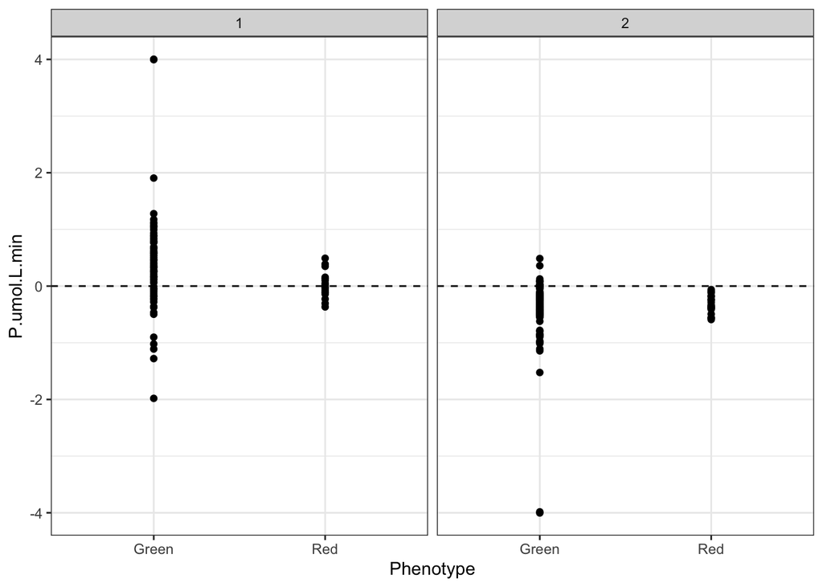

```r
oxygen %>%
  filter(Type=="Blank") %>%
  ggplot(aes(Phenotype, P.umol.L.min))+
  geom_point()+
  geom_hline(yintercept=0, linetype="dashed", color = "black")+
  facet_wrap(vars(Light))+
  theme_bw()
```

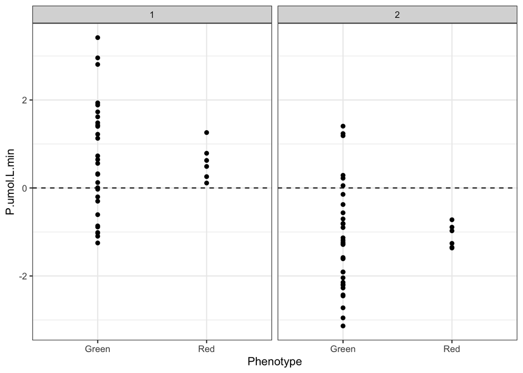

```r
oxygen %>%
  filter(Type=="Sample") %>%
  ggplot(aes(Phenotype, P.umol.L.min))+
  geom_point()+
  geom_hline(yintercept=0, linetype="dashed", color = "black")+
  facet_wrap(vars(Light))+
  theme_bw()
```

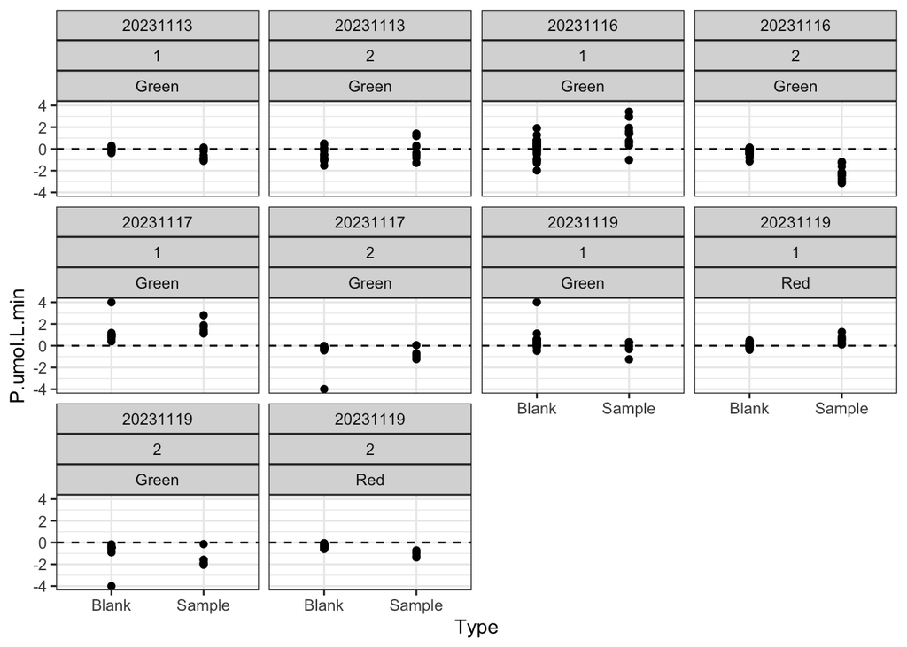

```r
oxygen %>%
  ggplot(aes(Type, P.umol.L.min))+
  geom_point()+
  geom_hline(yintercept=0, linetype="dashed", color = "black")+
  facet_wrap(vars(Date, Light, Phenotype), ncol=4)+
  theme_bw()
```

Remove samples that have inaccurate slope extraction for respiration rates (determined by PDF output files and outlier plots and data filled in for “No Sensor” as a test of the code function )

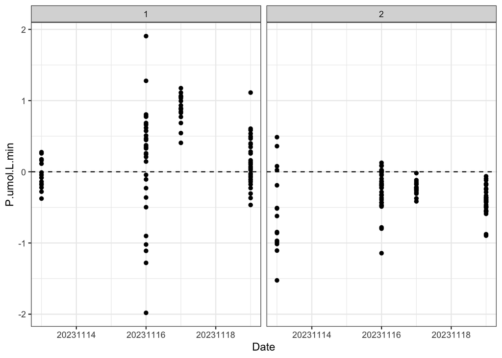

```r
oxygen<-oxygen%>%
  filter(!(unique=="202311174D5")) %>%
  filter(!(unique=="202311175D5")) %>%
  filter(!(unique=="202311195D5")) %>%
  filter(!(unique=="202311176D5")) %>%
  filter(!(unique=="202311196D5"))

oxygen %>%
  filter(Type=="Blank") %>%
  ggplot(aes(Date, P.umol.L.min))+
  geom_point()+
  geom_hline(yintercept=0, linetype="dashed", color = "black")+
  facet_wrap(vars(Light))+
  theme_bw()
```

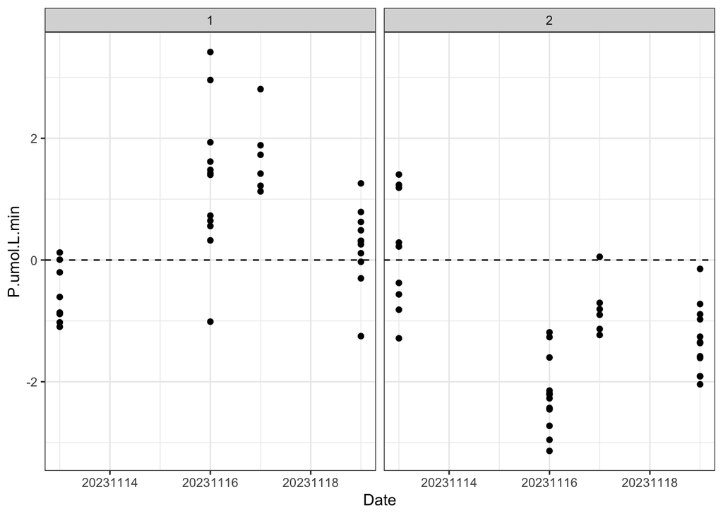

```r
oxygen %>%
  filter(Type=="Sample") %>%
  ggplot(aes(Date, P.umol.L.min))+
  geom_point()+
  geom_hline(yintercept=0, linetype="dashed", color = "black")+
  facet_wrap(vars(Light))+
  theme_bw()
```

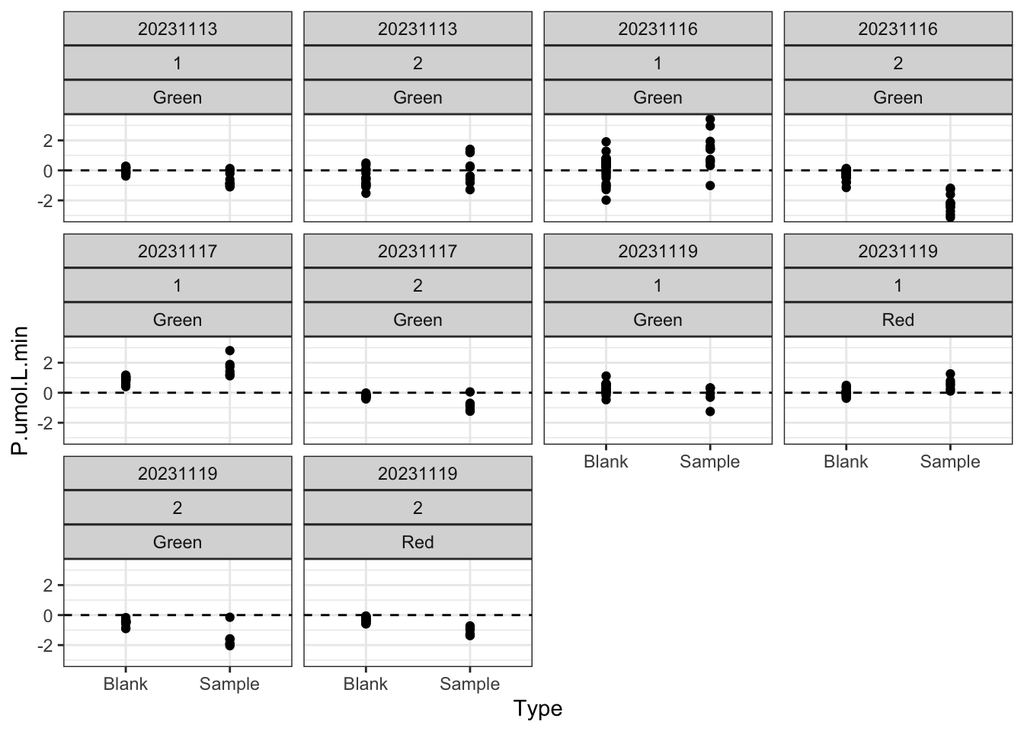

```r
oxygen %>%
  ggplot(aes(Type, P.umol.L.min))+
  geom_point()+
  geom_hline(yintercept=0, linetype="dashed", color = "black")+
  facet_wrap(vars(Date, Light, Phenotype), ncol=4)+
  theme_bw()
```

Account for volume to obtain umol per minute.

```r
#Account for chamber volume to convert from umol L-1 m-1 to umol m-1. This removes per Liter
oxygen$P.umol.min <- oxygen$P.umol.L.min * oxygen$Volume #calculate
```

Check the data from the test of the Number of Larvae needed to get a signal

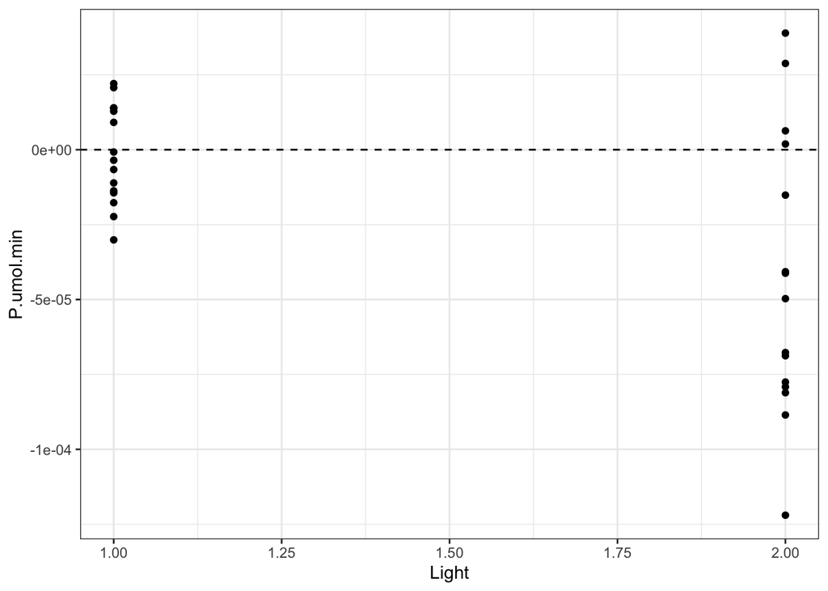

```r
#filter test data

test.number.data <- oxygen %>%
  filter(Date==20231113)

#Subtract blank values. Average blank calculated for each run. Display mean blank
test_blank_data <- subset(test.number.data, Type == "Blank") #subset to blank data only

test_blank_data %>%
  ggplot(aes(Light, P.umol.min))+
  geom_point()+
  geom_hline(yintercept=0, linetype="dashed", color = "black")+
  theme_bw()
```

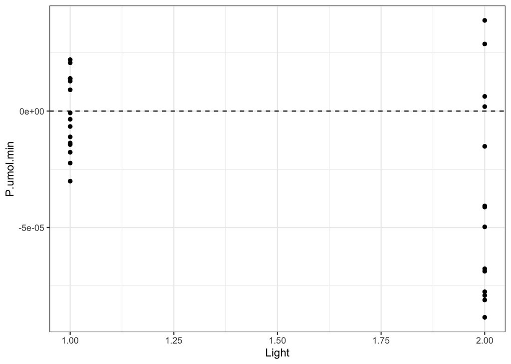

```r
#remove high outlier blanks
test_blank_data <- test_blank_data %>%
  filter(!P.umol.min>1.0e-04)

#remove low outlier blanks
test_blank_data <- test_blank_data %>%
  filter(!P.umol.min < (-1.0e-04))

test_blank_data %>%
  ggplot(aes(Light, P.umol.min))+
  geom_point()+
  geom_hline(yintercept=0, linetype="dashed", color = "black")+
  theme_bw()
```